# Social Network Analysis of the Canadian Disability Rights Community

Mapping Collaboration Networks and Key Actors in Disability Rights Advocacy

Enquête d'analyse des Réseaux Sociaux / Social Network Analysis Survey — March 2026

## 1. Executive Summary

This report presents a Social Network Analysis (SNA) of collaboration patterns within the Canadian disability rights community, based on a bilingual survey (English/French) of 111 respondents. The analysis maps who collaborates with whom, identifies the most central actors and organizations, detects community clusters, and assesses overall network structure.

111

Survey Respondents

57

Named Collaborators

166

Unique Organizations

182

Collaboration Ties

**Key Finding:** The network is highly fragmented — most organizations were named by only one respondent, and the projected respondent network has 46 disconnected components among 57 nodes. A small number of organizations (notably Disability Without Poverty, CNIB, and March of Dimes) serve as the primary connective tissue between actors. This suggests the Canadian disability rights community operates through many localized, issue-specific partnerships rather than a tightly integrated national network.

## 2. Two-Mode Network: Respondents and Issue Areas

The bipartite network below maps respondents (circles, colored by their connection type to the disability community) to the disability rights issue areas they are most actively involved in (squares). This reveals which issues attract the most engagement and which types of actors cluster around which topics.

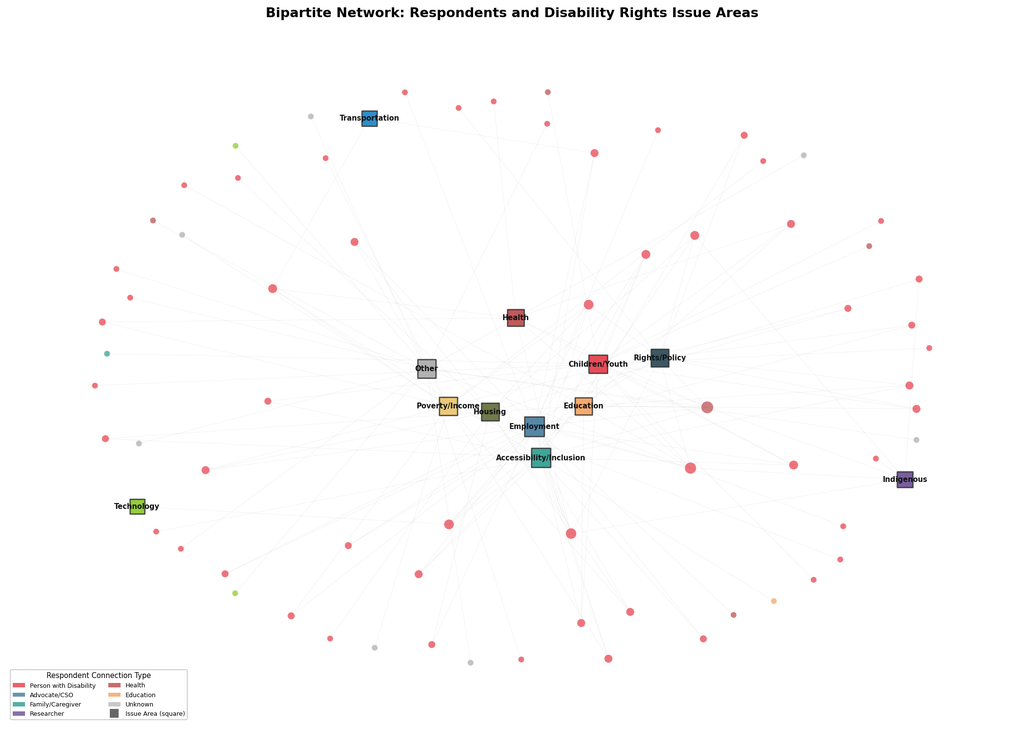

Figure 1. Two-mode bipartite network. Circle nodes represent individual respondents (colored by connection type); square nodes represent disability rights issue areas (sized by number of affiliated respondents). Layout: Fruchterman-Reingold force-directed algorithm.

## 3. One-Mode Projected Network: Respondent Collaboration

The projected network links two respondents if they named the same organization as a collaboration partner. Edge width reflects the number of shared partners. This reveals the "hidden" relational structure — which respondents are indirectly connected through common organizational affiliations.

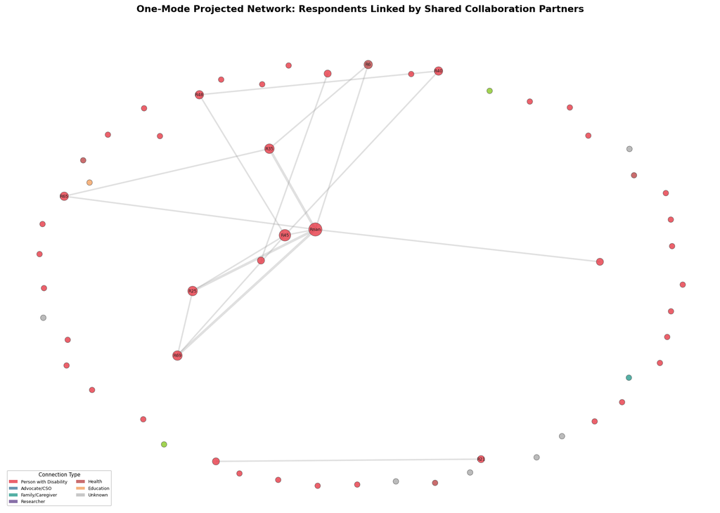

Figure 2. One-mode projected network. Respondents are linked when they share at least one named collaboration partner. Node size reflects degree centrality; color indicates connection type. Edge width reflects the number of shared partners.

The network is sparse (density = 0.0107) with 46 components, indicating a highly decentralized collaboration landscape. The largest connected component contains 10 respondents. Most respondents are isolates in the projected network — meaning their named partners were unique to them and not shared with other survey participants. The few clusters that do form tend to centre around nationally recognized disability organizations.

### Network Structure Metrics

| Nodes (respondents with collaboration ties) | 57 |
| --- | --- |
| Edges (shared-partner links) | 17 |
| Density | 0.0107 |
| Connected components | 46 |
| Transitivity (global clustering coefficient) | 0.4773 |
| Average clustering coefficient | 0.1282 |
| Largest component size | 10 |

## 4. Centrality Analysis

Centrality measures identify the most influential actors in the network. Degree centrality counts direct connections; betweenness centrality identifies actors who serve as bridges between otherwise disconnected parts of the network.

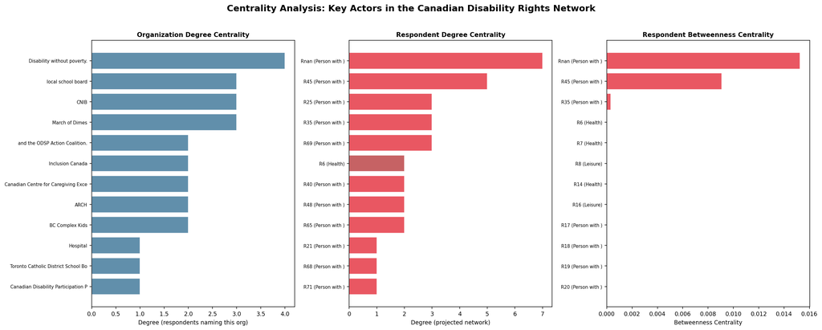

Figure 3. Centrality analysis across three measures. Left: Organization degree centrality (number of respondents naming each org). Centre: Respondent degree centrality in the projected network. Right: Respondent betweenness centrality (bridging role).

Among organizations, Disability Without Poverty is the most frequently named collaboration partner (degree = 4), followed by CNIB, March of Dimes, and local school boards (each degree = 3). These organizations function as the connective hubs of the network.

Among respondents, those with the highest betweenness centrality occupy critical bridging positions — they connect clusters of respondents who would otherwise be entirely disconnected. The most central respondents tend to be persons with disabilities who are engaged across multiple issue areas.

## 5. Community Detection

The Louvain community detection algorithm identified 47 communities with a modularity score of 0.3387. Due to the network's high fragmentation, most "communities" are isolates or pairs. The meaningful multi-member communities are summarized below.

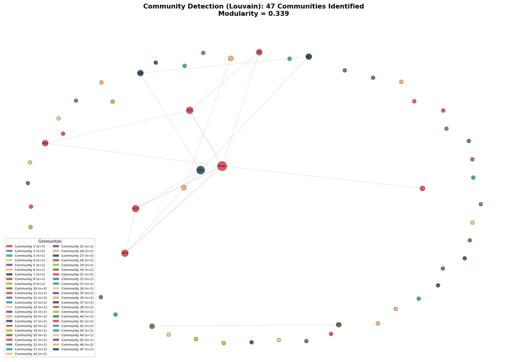

Figure 4. Community detection using the Louvain algorithm. Each color represents a detected community. Node size reflects degree centrality.

### Multi-Member Communities

| Community | Size | Connection Types | Issue Areas |
| --- | --- | --- | --- |
| Community 1 | 7 | Person with Disability (6), Health (1) | Children/Youth (3), Employment (1), Rights/Policy (1) |
| Community 10 | 2 | Person with Disability (2) | Poverty/Income (1), Employment (1) |
| Community 27 | 3 | Person with Disability (3) | Housing (1), Employment (1), Other (1) |
| Community 46 | 2 | Person with Disability (2) | Children/Youth (2) |

The largest community (n=7) is dominated by persons with disabilities focused on Children/Youth issues. This is the primary cohesive cluster in the network, connected through shared partnerships with organizations like school boards and children's disability services. The remaining multi-member communities are small dyads or triads united by shared organizational affiliations.

## 6. Degree Distributions and Collaboration Patterns

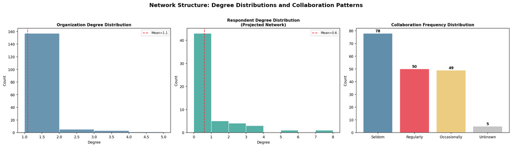

Figure 5. Left: Organization degree distribution (most orgs named by only 1 respondent). Centre: Respondent degree distribution in the projected network (most respondents are isolates). Right: Collaboration frequency across all reported ties.

The degree distributions confirm the network's fragmented structure. The organization degree distribution follows a power-law-like pattern: the vast majority of organizations (mean degree = 1.1) were named by only one respondent, while a small number serve as shared hubs. In the projected respondent network, most actors have degree 0 (isolates), with a long tail of a few well-connected individuals.

## 7. Discussion and Implications

### Fragmentation as a structural feature

The Canadian disability rights community, as captured by this survey, operates as a highly decentralized network. Collaboration is predominantly local and issue-specific rather than nationally integrated. This is not necessarily a weakness — it may reflect the diversity of disability issues and the importance of place-based advocacy — but it does mean that information, resources, and strategic coordination may not flow easily across the network.

### The role of national organizations

A small number of national organizations (Disability Without Poverty, CNIB, March of Dimes, Inclusion Canada) serve as critical connectors. These organizations' capacity to convene, share information, and bridge across issue silos is disproportionately important to overall network cohesion. Strengthening these hub organizations — or creating new ones — could substantially improve coordination across the community.

### Bridging actors

Respondents with high betweenness centrality are structurally important: they connect otherwise isolated parts of the network. Supporting and amplifying these bridging actors — many of whom are persons with disabilities themselves — could enhance cross-pollination of ideas and strategies.

### Limitations

This analysis is based on a convenience sample of 111 respondents. The free-text partner naming format means some organizations may be inconsistently recorded. The projected one-mode network relies on the assumption that shared organizational partnerships indicate a meaningful indirect connection between respondents. Finally, the survey captures reported collaboration, which may differ from actual interaction patterns.

Report generated from the Enquête d'analyse des Réseaux Sociaux / Social Network Analysis Survey. Analysis performed using Python (NetworkX, python-louvain, matplotlib). All respondent identifiers are de-identified survey IDs.